# Problem Statement

[figure not shown]

The sinking of the Titanic is one of the most infamous shipwrecks in history.

On April 15, 1912, during her maiden voyage, the widely considered “unsinkable” RMS Titanic sank after colliding with an iceberg. Unfortunately, there weren’t enough lifeboats for everyone onboard, resulting in the death of 1502 out of 2224 passengers and crew.

While there was some element of luck involved in surviving, it seems some groups of people were more likely to survive than others.

In this challenge, we ask you to build a predictive model that answers the question: “what sorts of people were more likely to survive?” using passenger data (ie name, age, gender, socio-economic class, etc).

**Data Dictionary**

| **Variable** | **Definition** | **Key** |
| --- | --- | --- |
| survival | Survival | 0 = No, 1 = Yes |
| pclass | Ticket class | 1 = 1st, 2 = 2nd, 3 = 3rd |
| sex | Sex |  |
| Age | Age in years |  |
| sibsp | # of siblings / spouses aboard the Titanics |  |
| parch | # of parents / children aboard the Titanic |  |
| ticket | Ticket number |  |
| fare | Passenger fare |  |
| cabin | Cabin number |  |
| embarked | Port of Embarkation | C = Cherbourg, Q = Queenstown, S = Southampton |

**Variable Notes**

**pclass**: A proxy for socio-economic status (SES)

1st = Upper

2nd = Middle

3rd = Lower

**age**: Age is fractional if less than 1. If the age is estimated, is it in the form of xx.5

**sibsp**: The dataset defines family relations in this way...

Sibling = brother, sister, stepbrother, stepsister

Spouse = husband, wife (mistresses and fiancés were ignored)

**parch**: The dataset defines family relations in this way...

Parent = mother, father

Child = daughter, son, stepdaughter, stepson

Some children travelled only with a nanny, therefore parch=0 for them.

**Goal**

It is your job to predict if a passenger survived the sinking of the Titanic or not. For each in the test set, you must predict a 0 or 1 value for the variable.

**Metric**

Your score is the percentage of passengers you correctly predict. This is known as accuracy.

Reference Link : https://www.kaggle.com/c/titanic/overview

```python
########################################### Titanic Problem ####################################################################
```

```python
## Import necessary libraries

import numpy as np ## Numpy Library ( will use to convert data frame to array or creating array etc...).
import pandas as pd ## Pandas Library (will use to load data,create data frame...etc).
import os ## For connecting to machine to get path for reading/writing files.
import matplotlib.pyplot as plt ## For visulaization.
import seaborn as sns ## For visulaization.
from sklearn.model_selection import train_test_split ## For splitting data into train and validation.
from sklearn.impute import SimpleImputer ## For imputing NA values.
from sklearn.preprocessing import StandardScaler ## For scaling numeric columns.
from sklearn.tree import DecisionTreeClassifier,export_graphviz ## For decision tree model.
from sklearn.metrics import accuracy_score, recall_score, precision_score,confusion_matrix,mean_absolute_error,mean_squared_error,classification_report ## For metrics.
from sklearn.model_selection import  GridSearchCV ## For Grid search moel.
from sklearn.linear_model import LogisticRegression ## For Logistic model.
from sklearn.metrics import roc_curve ## For ROC curve.
from sklearn.naive_bayes import GaussianNB ## For NaiveBayes model.
from sklearn.neighbors import KNeighborsClassifier ## For KNN model.
from sklearn.ensemble import RandomForestClassifier ## For Random Forest model.
from sklearn.ensemble import BaggingClassifier ## For Bagging model.
from sklearn.ensemble import AdaBoostClassifier ## For AdaBoost model.
from sklearn.ensemble import GradientBoostingClassifier ## For GB model.
from xgboost.sklearn import XGBClassifier ## For XGB model.
from sklearn.svm import SVC ## For SVC model.
from keras.models import Sequential, Model ## For sequential model.
from keras.layers import Dense, Input ## For input,dense model.
from sklearn.linear_model import RidgeClassifier, Lasso ## For Ridge,Lasso Model.
```

```python
## Get current working directory path.
os.getcwd()
```

```
'D:\\DataScience\\Pratice\\Titanic'
```

```python
## Set working directoy.
os.chdir("D:\\DataScience\\Pratice\\Titanic")
```

```python
## Set max how many rows and columns you want to display in jupyter notebook.
pd.options.display.max_columns = 200
pd.get_option('display.max_rows')
pd.set_option('display.max_rows',None)
```

```python
## Read titanic train data set.
data = pd.read_csv("train.csv",header='infer',sep=',')
```

```python
## Read titanic test data set.
test_data = pd.read_csv("test.csv",header='infer',sep=',')
```

```python
## Get first 5 records of train data.
data.head()
```

|  | PassengerId | Survived | Pclass | Name | Sex | Age | SibSp | Parch | Ticket | Fare | Cabin | Embarked |
| --- | --- | --- | --- | --- | --- | --- | --- | --- | --- | --- | --- | --- |
| 0 | 1 | 0 | 3 | Braund, Mr. Owen Harris | male | 22.0 | 1 | 0 | A/5 21171 | 7.2500 | NaN | S |
| 1 | 2 | 1 | 1 | Cumings, Mrs. John Bradley (Florence Briggs Th... | female | 38.0 | 1 | 0 | PC 17599 | 71.2833 | C85 | C |
| 2 | 3 | 1 | 3 | Heikkinen, Miss. Laina | female | 26.0 | 0 | 0 | STON/O2. 3101282 | 7.9250 | NaN | S |
| 3 | 4 | 1 | 1 | Futrelle, Mrs. Jacques Heath (Lily May Peel) | female | 35.0 | 1 | 0 | 113803 | 53.1000 | C123 | S |
| 4 | 5 | 0 | 3 | Allen, Mr. William Henry | male | 35.0 | 0 | 0 | 373450 | 8.0500 | NaN | S |

```python
## Get first 5 records of test data.
test_data.head()
```

|  | PassengerId | Pclass | Name | Sex | Age | SibSp | Parch | Ticket | Fare | Cabin | Embarked |
| --- | --- | --- | --- | --- | --- | --- | --- | --- | --- | --- | --- |
| 0 | 892 | 3 | Kelly, Mr. James | male | 34.5 | 0 | 0 | 330911 | 7.8292 | NaN | Q |
| 1 | 893 | 3 | Wilkes, Mrs. James (Ellen Needs) | female | 47.0 | 1 | 0 | 363272 | 7.0000 | NaN | S |
| 2 | 894 | 2 | Myles, Mr. Thomas Francis | male | 62.0 | 0 | 0 | 240276 | 9.6875 | NaN | Q |
| 3 | 895 | 3 | Wirz, Mr. Albert | male | 27.0 | 0 | 0 | 315154 | 8.6625 | NaN | S |
| 4 | 896 | 3 | Hirvonen, Mrs. Alexander (Helga E Lindqvist) | female | 22.0 | 1 | 1 | 3101298 | 12.2875 | NaN | S |

```python
## Get columns data types for train data.
data.dtypes
```

```
PassengerId      int64
Survived         int64
Pclass           int64
Name            object
Sex             object
Age            float64
SibSp            int64
Parch            int64
Ticket          object
Fare           float64
Cabin           object
Embarked        object
dtype: object
```

```python
## Get columns data types for test data.
test_data.dtypes
```

```
PassengerId      int64
Pclass           int64
Name            object
Sex             object
Age            float64
SibSp            int64
Parch            int64
Ticket          object
Fare           float64
Cabin           object
Embarked        object
dtype: object
```

```python
## Get summary statistics of train data.
data.describe(include='all')
```

|  | PassengerId | Survived | Pclass | Name | Sex | Age | SibSp | Parch | Ticket | Fare | Cabin | Embarked |
| --- | --- | --- | --- | --- | --- | --- | --- | --- | --- | --- | --- | --- |
| count | 891.000000 | 891.000000 | 891.000000 | 891 | 891 | 714.000000 | 891.000000 | 891.000000 | 891 | 891.000000 | 204 | 889 |
| unique | NaN | NaN | NaN | 891 | 2 | NaN | NaN | NaN | 681 | NaN | 147 | 3 |
| top | NaN | NaN | NaN | Phillips, Miss. Kate Florence ("Mrs Kate Louis... | male | NaN | NaN | NaN | 1601 | NaN | G6 | S |
| freq | NaN | NaN | NaN | 1 | 577 | NaN | NaN | NaN | 7 | NaN | 4 | 644 |
| mean | 446.000000 | 0.383838 | 2.308642 | NaN | NaN | 29.699118 | 0.523008 | 0.381594 | NaN | 32.204208 | NaN | NaN |
| std | 257.353842 | 0.486592 | 0.836071 | NaN | NaN | 14.526497 | 1.102743 | 0.806057 | NaN | 49.693429 | NaN | NaN |
| min | 1.000000 | 0.000000 | 1.000000 | NaN | NaN | 0.420000 | 0.000000 | 0.000000 | NaN | 0.000000 | NaN | NaN |
| 25% | 223.500000 | 0.000000 | 2.000000 | NaN | NaN | 20.125000 | 0.000000 | 0.000000 | NaN | 7.910400 | NaN | NaN |
| 50% | 446.000000 | 0.000000 | 3.000000 | NaN | NaN | 28.000000 | 0.000000 | 0.000000 | NaN | 14.454200 | NaN | NaN |
| 75% | 668.500000 | 1.000000 | 3.000000 | NaN | NaN | 38.000000 | 1.000000 | 0.000000 | NaN | 31.000000 | NaN | NaN |
| max | 891.000000 | 1.000000 | 3.000000 | NaN | NaN | 80.000000 | 8.000000 | 6.000000 | NaN | 512.329200 | NaN | NaN |

```python
## Get summary statistics of test data.
test_data.describe(include='all')
```

|  | PassengerId | Pclass | Name | Sex | Age | SibSp | Parch | Ticket | Fare | Cabin | Embarked |
| --- | --- | --- | --- | --- | --- | --- | --- | --- | --- | --- | --- |
| count | 418.000000 | 418.000000 | 418 | 418 | 332.000000 | 418.000000 | 418.000000 | 418 | 417.000000 | 91 | 418 |
| unique | NaN | NaN | 418 | 2 | NaN | NaN | NaN | 363 | NaN | 76 | 3 |
| top | NaN | NaN | Kink, Miss. Maria | male | NaN | NaN | NaN | PC 17608 | NaN | B57 B59 B63 B66 | S |
| freq | NaN | NaN | 1 | 266 | NaN | NaN | NaN | 5 | NaN | 3 | 270 |
| mean | 1100.500000 | 2.265550 | NaN | NaN | 30.272590 | 0.447368 | 0.392344 | NaN | 35.627188 | NaN | NaN |
| std | 120.810458 | 0.841838 | NaN | NaN | 14.181209 | 0.896760 | 0.981429 | NaN | 55.907576 | NaN | NaN |
| min | 892.000000 | 1.000000 | NaN | NaN | 0.170000 | 0.000000 | 0.000000 | NaN | 0.000000 | NaN | NaN |
| 25% | 996.250000 | 1.000000 | NaN | NaN | 21.000000 | 0.000000 | 0.000000 | NaN | 7.895800 | NaN | NaN |
| 50% | 1100.500000 | 3.000000 | NaN | NaN | 27.000000 | 0.000000 | 0.000000 | NaN | 14.454200 | NaN | NaN |
| 75% | 1204.750000 | 3.000000 | NaN | NaN | 39.000000 | 1.000000 | 0.000000 | NaN | 31.500000 | NaN | NaN |
| max | 1309.000000 | 3.000000 | NaN | NaN | 76.000000 | 8.000000 | 9.000000 | NaN | 512.329200 | NaN | NaN |

```python
## Get dimensions of train data.
data.shape
```

```
(891, 12)
```

```python
## Get dimensions of test data.
test_data.shape
```

```
(418, 11)
```

```python
## Get index range for train data.
data.index
```

```
RangeIndex(start=0, stop=891, step=1)
```

```python
## Get index range for test data.
test_data.index
```

```
RangeIndex(start=0, stop=418, step=1)
```

```python
## Get column names for train data.
data.columns
```

```
Index(['PassengerId', 'Survived', 'Pclass', 'Name', 'Sex', 'Age', 'SibSp',
       'Parch', 'Ticket', 'Fare', 'Cabin', 'Embarked'],
      dtype='object')
```

```python
## Get column names for test data.
test_data.columns
```

```
Index(['PassengerId', 'Pclass', 'Name', 'Sex', 'Age', 'SibSp', 'Parch',
       'Ticket', 'Fare', 'Cabin', 'Embarked'],
      dtype='object')
```

```python
## Check NA values for train data.
data.isna().sum()
```

```
PassengerId      0
Survived         0
Pclass           0
Name             0
Sex              0
Age            177
SibSp            0
Parch            0
Ticket           0
Fare             0
Cabin          687
Embarked         2
dtype: int64
```

```python
## Check NA values for test data.
test_data.isna().sum()
```

```
PassengerId      0
Pclass           0
Name             0
Sex              0
Age             86
SibSp            0
Parch            0
Ticket           0
Fare             1
Cabin          327
Embarked         0
dtype: int64
```

```python
## EDA
```

```python
## Get numer of persons surived based on gender.
data[["Sex", "Survived"]].groupby(['Sex'], as_index=False).mean().sort_values(by='Survived', ascending=False)
```

|  | Sex | Survived |
| --- | --- | --- |
| 0 | female | 0.742038 |
| 1 | male | 0.188908 |

```python
## Get numer of persons surived based on siblings.
data[["SibSp", "Survived"]].groupby(['SibSp'], as_index=False).mean().sort_values(by='Survived', ascending=False)
```

|  | SibSp | Survived |
| --- | --- | --- |
| 1 | 1 | 0.535885 |
| 2 | 2 | 0.464286 |
| 0 | 0 | 0.345395 |
| 3 | 3 | 0.250000 |
| 4 | 4 | 0.166667 |
| 5 | 5 | 0.000000 |
| 6 | 8 | 0.000000 |

```python
## Get numer of persons surived based on prach.
data[["Parch", "Survived"]].groupby(['Parch'], as_index=False).mean().sort_values(by='Survived', ascending=False)
```

|  | Parch | Survived |
| --- | --- | --- |
| 3 | 3 | 0.600000 |
| 1 | 1 | 0.550847 |
| 2 | 2 | 0.500000 |
| 0 | 0 | 0.343658 |
| 5 | 5 | 0.200000 |
| 4 | 4 | 0.000000 |
| 6 | 6 | 0.000000 |

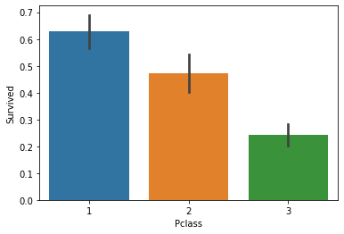

```python
## Display bar plot for pcalss vs survived.
sns.barplot(data['Pclass'],data['Survived']);
```

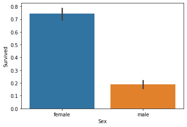

```python
## Display bar plot for gender vs survived.
sns.barplot(data['Sex'],data['Survived']);
```

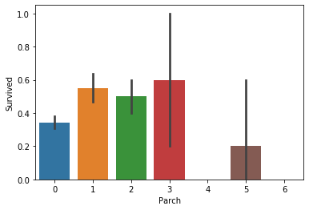

```python
## Display bar plot for Parch vs survived.
sns.barplot(data['Parch'], data['Survived']);
```

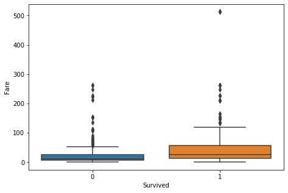

```python
## Display distribution plot for survived vs Fare.
plt.figure(figsize=(7.5,5))
sns.boxplot(data['Survived'], data['Fare']);
```

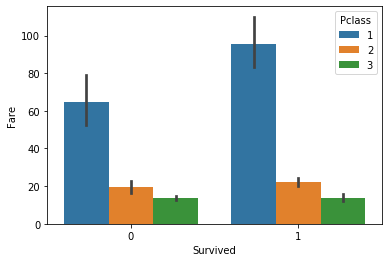

```python
## Display bar plot for survived,fare,pclass.
sns.barplot(data['Survived'], data['Fare'], data['Pclass']);
```

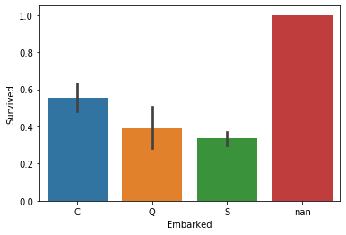

```python
## Display bar plot for embarked vs survived.
sns.barplot(data['Embarked'], data['Survived']);
```

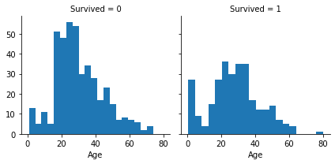

```python
## Plot face grid for survived vs age.
g = sns.FacetGrid(data, col='Survived')
g.map(plt.hist, 'Age', bins=20)
```

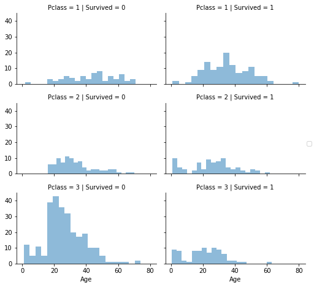

```python
## Plot face grid for survived vs age.
grid = sns.FacetGrid(data, col='Survived', row='Pclass', size=2.2, aspect=1.6)
grid.map(plt.hist, 'Age', alpha=.5, bins=20)
grid.add_legend();
```

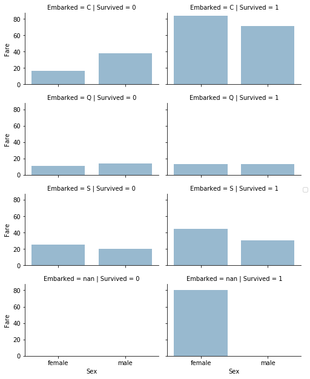

```python
## Plot face grid for survived,gender,fare,emarked and age.
grid = sns.FacetGrid(data, row='Embarked', col='Survived', size=2.2, aspect=1.6)
grid.map(sns.barplot, 'Sex', 'Fare', alpha=.5, ci=None)
grid.add_legend()
```

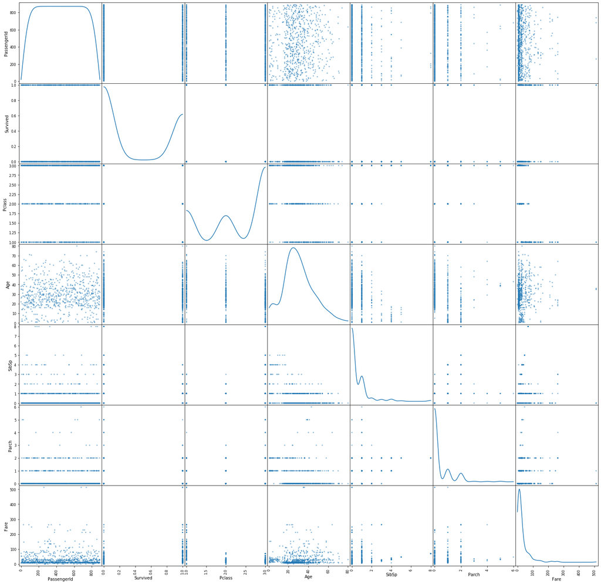

```python
## Display scatter plot for train data numeric columns.
pd.plotting.scatter_matrix(data, figsize=(25, 25), diagonal='kde')
plt.show()
```

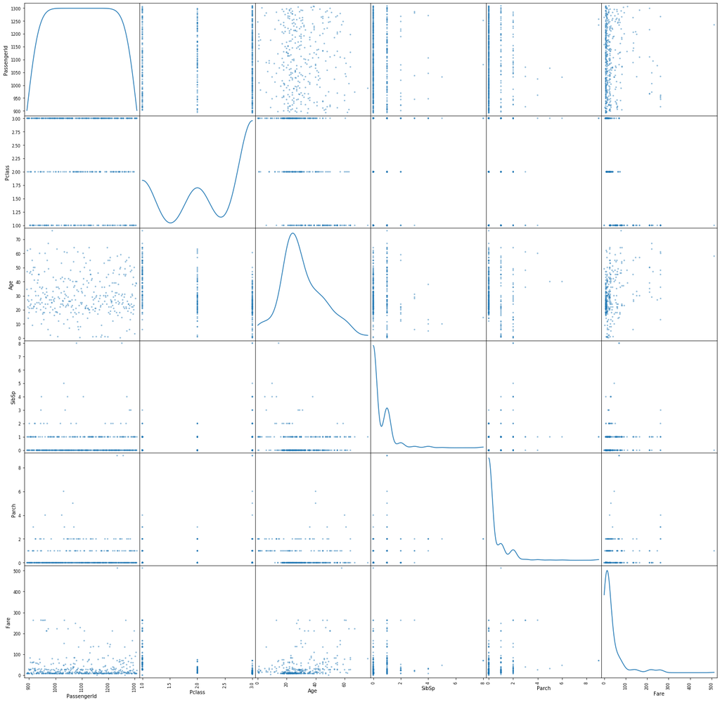

```python
## Display scatter plot for test data numeric columns.
pd.plotting.scatter_matrix(test_data, figsize=(25, 25), diagonal='kde')
plt.show()
```

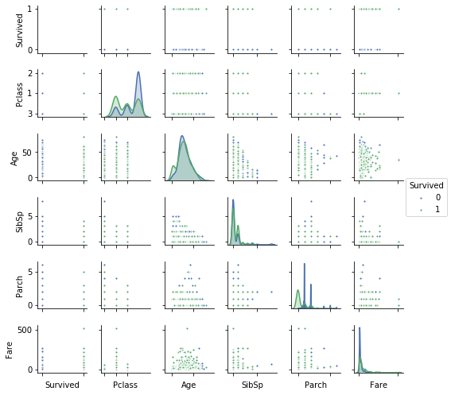

```python
## Display pair plot for numeric columns of train data.
pp = sns.pairplot(data, hue = 'Survived', palette = 'deep', size=1.2, diag_kind = 'kde', diag_kws=dict(shade=True), plot_kws=dict(s=10) )
pp.set(xticklabels=[])
```

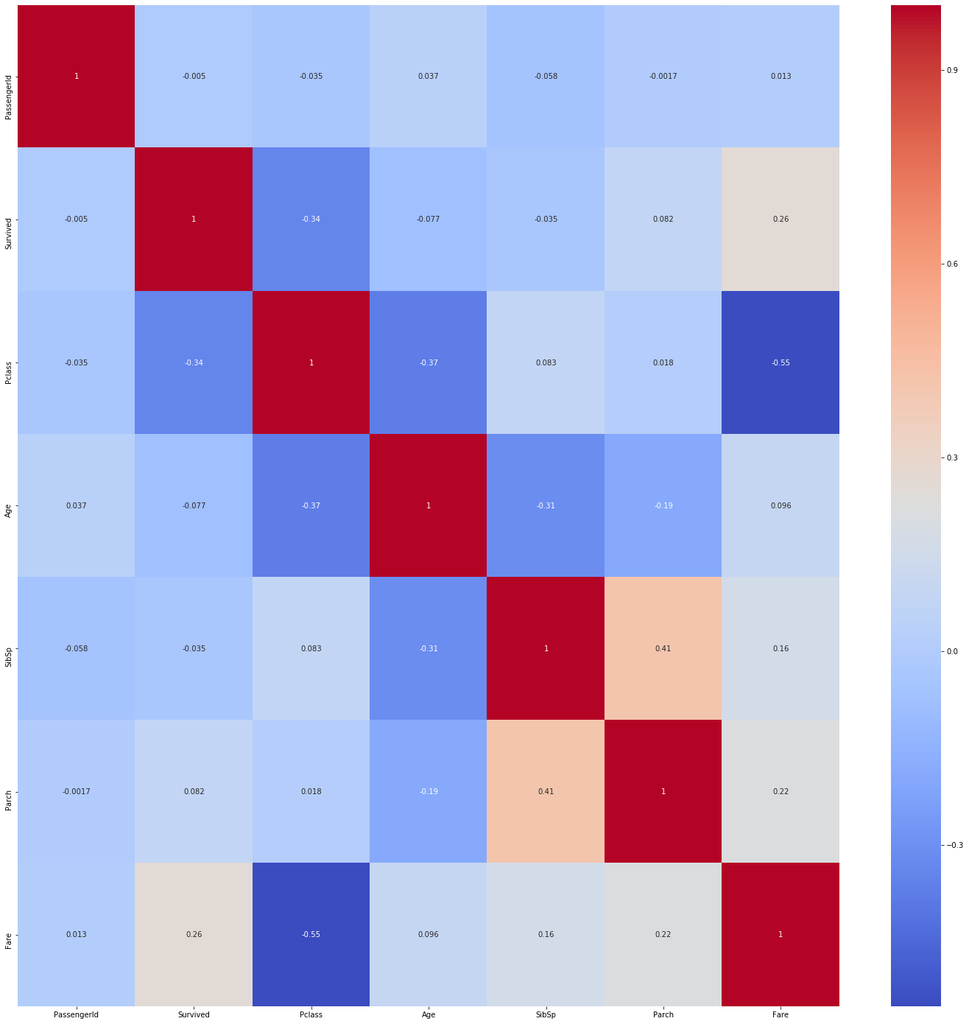

```python
## Display correlation plot for train data.
plt.figure(figsize=(25,25))
sns.heatmap(data.corr(),cmap='coolwarm',annot = True)
plt.show()
```

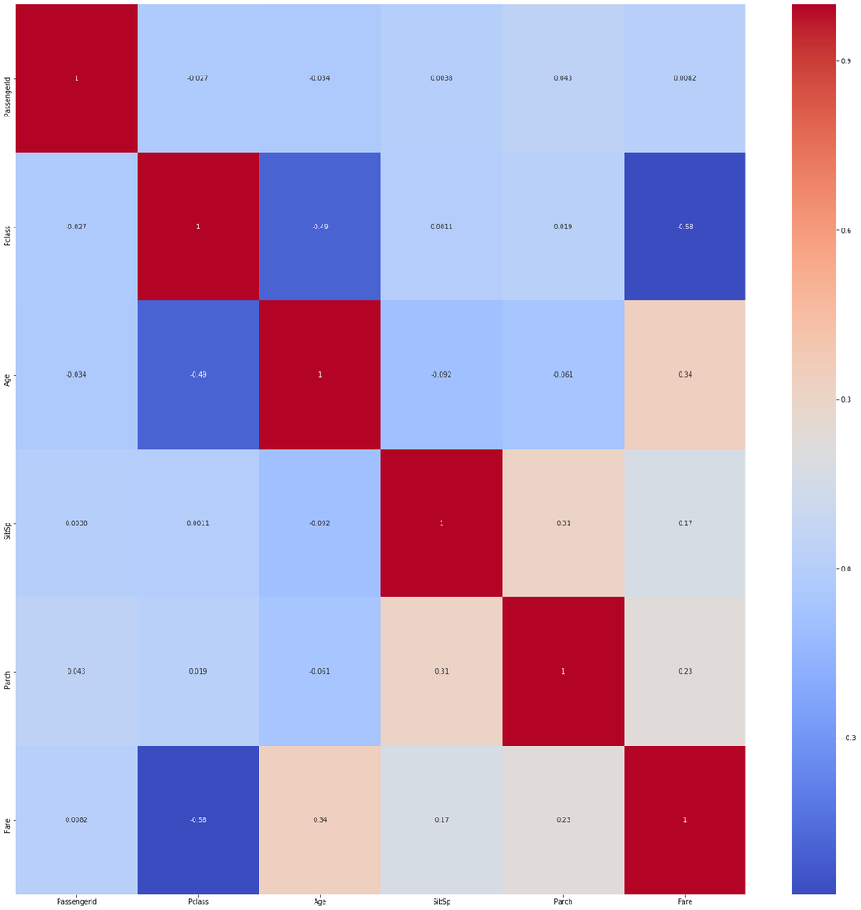

```python
## Display correlation plot for test data.
plt.figure(figsize=(25,25))
sns.heatmap(test_data.corr(),cmap='coolwarm',annot = True)
plt.show()
```

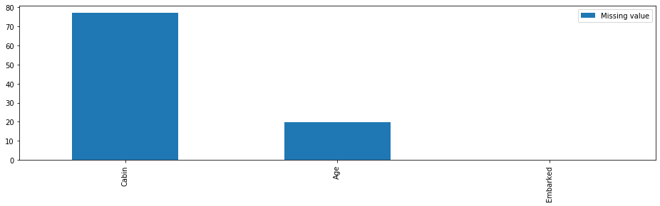

```python
#visualize missing data for train data.
missing_value = data.isnull().sum().sort_values(ascending=False) / len(data) * 100
missing_value = missing_value[missing_value != 0]
missing_value = pd.DataFrame({'Missing value' :missing_value,'Type':missing_value.index.map(lambda x:data[x].dtype)})
missing_value.plot(kind='bar',figsize=(16,4))
plt.show()
```

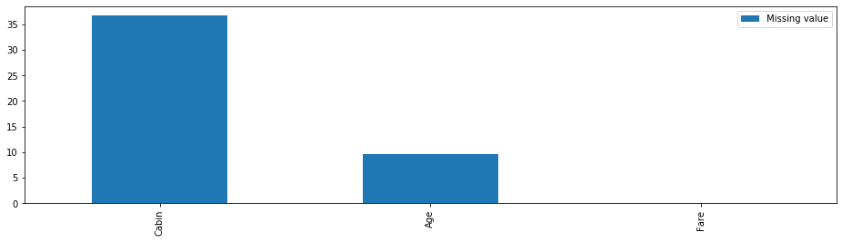

```python
#visualize missing data for test data.
missing_value = test_data.isnull().sum().sort_values(ascending=False) / len(data) * 100
missing_value = missing_value[missing_value != 0]
missing_value = pd.DataFrame({'Missing value' :missing_value,'Type':missing_value.index.map(lambda x:test_data[x].dtype)})
missing_value.plot(kind='bar',figsize=(16,4))
plt.show()
```

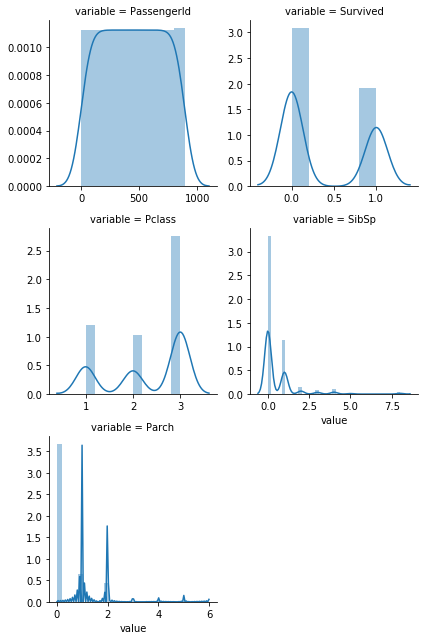

```python
## Display grid plot for train data numeric columns.
num_temp = data.select_dtypes('int64')
f = pd.melt(data, value_vars=num_temp)
g = sns.FacetGrid(f, col="variable",  col_wrap=2, sharex=False, sharey=False)
g = g.map(sns.distplot, "value")
```

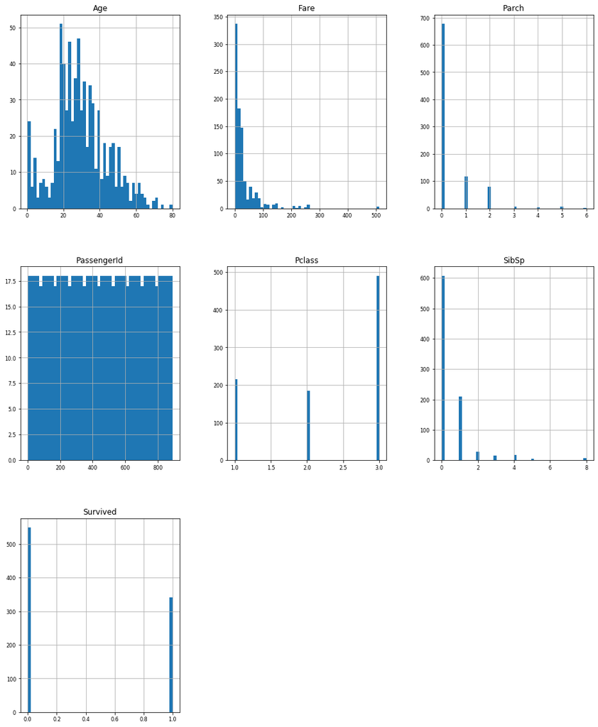

```python
## Display histogram plot for numeric columns of train data.
(data.select_dtypes(include = ['float64', 'int64'])).hist(figsize=(16, 20), bins=50, xlabelsize=8, ylabelsize=8);
```

```python
### find missing values % for train data.
missing_value = (data.isna().sum()/len(data)).round(4)*100
missing_value.sort_values(ascending=False)
#missing_value.count
```

```
Cabin          77.10
Age            19.87
Embarked        0.22
Fare            0.00
Ticket          0.00
Parch           0.00
SibSp           0.00
Sex             0.00
Name            0.00
Pclass          0.00
Survived        0.00
PassengerId     0.00
dtype: float64
```

```python
### find missing values % for test data.
missing_value = (test_data.isna().sum()/len(data)).round(4)*100
missing_value.sort_values(ascending=False)
#missing_value.count
```

```
Cabin          36.70
Age             9.65
Fare            0.11
Embarked        0.00
Ticket          0.00
Parch           0.00
SibSp           0.00
Sex             0.00
Name            0.00
Pclass          0.00
PassengerId     0.00
dtype: float64
```

```python
### This method will return number of levels,null values,unique values,data types.

def Observations(df):
    return(pd.DataFrame({'dtypes' : df.dtypes,
                         'levels' : [df[x].unique() for x in df.columns],
                         'null_values' : df.isna().sum(),
                         'Unique Values': df.nunique()
                        }))
## Get column data type,numer of levels,null values,unique values for each column of train data.
Observations(data)
```

|  | dtypes | levels | null_values | Unique Values |
| --- | --- | --- | --- | --- |
| PassengerId | int64 | [1, 2, 3, 4, 5, 6, 7, 8, 9, 10, 11, 12, 13, 14... | 0 | 891 |
| Survived | int64 | [0, 1] | 0 | 2 |
| Pclass | int64 | [3, 1, 2] | 0 | 3 |
| Name | object | [Braund, Mr. Owen Harris, Cumings, Mrs. John B... | 0 | 891 |
| Sex | object | [male, female] | 0 | 2 |
| Age | float64 | [22.0, 38.0, 26.0, 35.0, nan, 54.0, 2.0, 27.0,... | 177 | 88 |
| SibSp | int64 | [1, 0, 3, 4, 2, 5, 8] | 0 | 7 |
| Parch | int64 | [0, 1, 2, 5, 3, 4, 6] | 0 | 7 |
| Ticket | object | [A/5 21171, PC 17599, STON/O2. 3101282, 113803... | 0 | 681 |
| Fare | float64 | [7.25, 71.2833, 7.925, 53.1, 8.05, 8.4583, 51.... | 0 | 248 |
| Cabin | object | [nan, C85, C123, E46, G6, C103, D56, A6, C23 C... | 687 | 147 |
| Embarked | object | [S, C, Q, nan] | 2 | 3 |

```python
## Drop unsignificant columns for train data.
unsignificant_Col = ['Name','Ticket','Cabin']
data.drop(unsignificant_Col,axis=1,inplace=True)
```

```python
## Check first 5 records of train data after dropping unsignificant columns.
data.head()
```

|  | PassengerId | Survived | Pclass | Sex | Age | SibSp | Parch | Fare | Embarked |
| --- | --- | --- | --- | --- | --- | --- | --- | --- | --- |
| 0 | 1 | 0 | 3 | male | 22.0 | 1 | 0 | 7.2500 | S |
| 1 | 2 | 1 | 1 | female | 38.0 | 1 | 0 | 71.2833 | C |
| 2 | 3 | 1 | 3 | female | 26.0 | 0 | 0 | 7.9250 | S |
| 3 | 4 | 1 | 1 | female | 35.0 | 1 | 0 | 53.1000 | S |
| 4 | 5 | 0 | 3 | male | 35.0 | 0 | 0 | 8.0500 | S |

```python
## Get column data type,numer of levels,null values,unique values for each column of test data.
Observations(test_data)
```

|  | dtypes | levels | null_values | Unique Values |
| --- | --- | --- | --- | --- |
| PassengerId | int64 | [892, 893, 894, 895, 896, 897, 898, 899, 900, ... | 0 | 418 |
| Pclass | int64 | [3, 2, 1] | 0 | 3 |
| Name | object | [Kelly, Mr. James, Wilkes, Mrs. James (Ellen N... | 0 | 418 |
| Sex | object | [male, female] | 0 | 2 |
| Age | float64 | [34.5, 47.0, 62.0, 27.0, 22.0, 14.0, 30.0, 26.... | 86 | 79 |
| SibSp | int64 | [0, 1, 2, 3, 4, 5, 8] | 0 | 7 |
| Parch | int64 | [0, 1, 3, 2, 4, 6, 5, 9] | 0 | 8 |
| Ticket | object | [330911, 363272, 240276, 315154, 3101298, 7538... | 0 | 363 |
| Fare | float64 | [7.8292, 7.0, 9.6875, 8.6625, 12.2875, 9.225, ... | 1 | 169 |
| Cabin | object | [nan, B45, E31, B57 B59 B63 B66, B36, A21, C78... | 327 | 76 |
| Embarked | object | [Q, S, C] | 0 | 3 |

```python
## Drop unsinificant columns for test data.
test_data.drop(unsignificant_Col,axis=1,inplace=True)
```

```python
## Check first 5 records of test data after dropping unsignificant columns.
test_data.head()
```

|  | PassengerId | Pclass | Sex | Age | SibSp | Parch | Fare | Embarked |
| --- | --- | --- | --- | --- | --- | --- | --- | --- |
| 0 | 892 | 3 | male | 34.5 | 0 | 0 | 7.8292 | Q |
| 1 | 893 | 3 | female | 47.0 | 1 | 0 | 7.0000 | S |
| 2 | 894 | 2 | male | 62.0 | 0 | 0 | 9.6875 | Q |
| 3 | 895 | 3 | male | 27.0 | 0 | 0 | 8.6625 | S |
| 4 | 896 | 3 | female | 22.0 | 1 | 1 | 12.2875 | S |

```python
## Convert numeric into category for train data.
data['Pclass'] = data['Pclass'].astype('str').astype('category')
```

```python
## Convert numeric into category for test data.
test_data['Pclass'] = test_data['Pclass'].astype('str').astype('category')
```

```python
## Fetch category,object data types columns for train data.
object_columns = data.select_dtypes(include=['object','category'])
```

```python
## Fetch category,object data types columns for test data.
test_object_columns = test_data.select_dtypes(include=['object','category'])
```

```python
## Convert object to category data type for train data.
for col in object_columns.columns:
    data[col] = data[col].astype('str').astype('category')
```

```python
## Convert object to category data type for test data.
for col in test_object_columns.columns:
    test_data[col] = test_data[col].astype('str').astype('category')
```

```python
## Check column data types for train data.
data.dtypes
```

```
PassengerId       int64
Survived          int64
Pclass         category
Sex            category
Age             float64
SibSp             int64
Parch             int64
Fare            float64
Embarked       category
dtype: object
```

```python
## Check column data types for test data.
test_data.dtypes
```

```
PassengerId       int64
Pclass         category
Sex            category
Age             float64
SibSp             int64
Parch             int64
Fare            float64
Embarked       category
dtype: object
```

```python
## Set PassengerId column as index to train data and display first 5 records.
data = data.set_index('PassengerId')
data.head()
```

| PassengerId | Survived | Pclass | Sex | Age | SibSp | Parch | Fare | Embarked |
| --- | --- | --- | --- | --- | --- | --- | --- | --- |
| 1 | 0 | 3 | male | 22.0 | 1 | 0 | 7.2500 | S |
| 2 | 1 | 1 | female | 38.0 | 1 | 0 | 71.2833 | C |
| 3 | 1 | 3 | female | 26.0 | 0 | 0 | 7.9250 | S |
| 4 | 1 | 1 | female | 35.0 | 1 | 0 | 53.1000 | S |
| 5 | 0 | 3 | male | 35.0 | 0 | 0 | 8.0500 | S |

```python
## Set PassengerId column as index to test data and display first 5 records.
test_data = test_data.set_index('PassengerId')
test_data.head()
```

| PassengerId | Pclass | Sex | Age | SibSp | Parch | Fare | Embarked |
| --- | --- | --- | --- | --- | --- | --- | --- |
| 892 | 3 | male | 34.5 | 0 | 0 | 7.8292 | Q |
| 893 | 3 | female | 47.0 | 1 | 0 | 7.0000 | S |
| 894 | 2 | male | 62.0 | 0 | 0 | 9.6875 | Q |
| 895 | 3 | male | 27.0 | 0 | 0 | 8.6625 | S |
| 896 | 3 | female | 22.0 | 1 | 1 | 12.2875 | S |

```python
## Seperate numeric and categorical columns for train data.
cat_columns = data.select_dtypes(include=['category'])
num_columns = data.select_dtypes(include=['int64', 'float64'])
```

```python
## Seperate numeric and categorical columns for test data.
test_cat_columns = test_data.select_dtypes(include=['category'])
test_num_columns = test_data.select_dtypes(include=['int64', 'float64'])
```

```python
## Below logic is used for checking for special charcter in numeric columns of train data.

for col in num_columns.columns:

    print('\n',col,'----->')
    for index in range(1,len(data)):
        try:
            skip=float(data.loc[index,col])
            skip=int(data.loc[index,col])
        except ValueError :
            print(index,data.loc[index,col])
```

[output not shown]

[output cut: 171 more lines]

```python
## Check special characters for categorical columns of train data.
for col in cat_columns.columns:
    print('\n',col,'----->')
    for index in range(1,len(data)):
        if  data.loc[index,col].isdigit() or data.loc[index,col]==' ' or data.loc[index,col].isalpha():
            skip = True
        else:
            print("Index ",index,"\tSpecial Character ",data.loc[index,col])
```

```
 Pclass ----->

 Sex ----->

 Embarked ----->
```

```python
## Check correlation for numeric columns of train data.
data[num_columns.columns].corr()
```

|  | Survived | Age | SibSp | Parch | Fare |
| --- | --- | --- | --- | --- | --- |
| Survived | 1.000000 | -0.077221 | -0.035322 | 0.081629 | 0.257307 |
| Age | -0.077221 | 1.000000 | -0.308247 | -0.189119 | 0.096067 |
| SibSp | -0.035322 | -0.308247 | 1.000000 | 0.414838 | 0.159651 |
| Parch | 0.081629 | -0.189119 | 0.414838 | 1.000000 | 0.216225 |
| Fare | 0.257307 | 0.096067 | 0.159651 | 0.216225 | 1.000000 |

```python
## Check correlation for numeric columns of test data.
test_data[test_num_columns.columns].corr()
```

|  | Age | SibSp | Parch | Fare |
| --- | --- | --- | --- | --- |
| Age | 1.000000 | -0.091587 | -0.061249 | 0.337932 |
| SibSp | -0.091587 | 1.000000 | 0.306895 | 0.171539 |
| Parch | -0.061249 | 0.306895 | 1.000000 | 0.230046 |
| Fare | 0.337932 | 0.171539 | 0.230046 | 1.000000 |

```python
## Calculate variance for numeric columns.
def variance(x):
        return(pd.DataFrame({'Datatype' : x.dtypes,
                            'Variance': [round(x[i].var()) for i in x] }))

## Get varience for numeric columns of train data.
variance(num_columns)
```

|  | Datatype | Variance |
| --- | --- | --- |
| Survived | int64 | 0 |
| Age | float64 | 211 |
| SibSp | int64 | 1 |
| Parch | int64 | 1 |
| Fare | float64 | 2469 |

```python
## Get varience for numeric columns of test data.
variance(test_num_columns)
```

|  | Datatype | Variance |
| --- | --- | --- |
| Age | float64 | 201 |
| SibSp | int64 | 1 |
| Parch | int64 | 1 |
| Fare | float64 | 3126 |

```python
## Seperate Target and Predictors from train data and display dimensions of it's.

features = data.drop('Survived', axis = 1)
print(features.shape)
target = data['Survived']
print(target.shape)
```

```
(891, 7)
(891,)
```

```python
## Split the data into train and validation(70:30 ratio).
X_train,X_test,y_train,y_test=train_test_split(features,target,test_size=0.3,random_state=123)
```

```python
## Get first 5 records of train data.
X_train.head()
```

| PassengerId | Pclass | Sex | Age | SibSp | Parch | Fare | Embarked |
| --- | --- | --- | --- | --- | --- | --- | --- |
| 417 | 2 | female | 34.0 | 1 | 1 | 32.5000 | S |
| 802 | 2 | female | 31.0 | 1 | 1 | 26.2500 | S |
| 513 | 1 | male | 36.0 | 0 | 0 | 26.2875 | S |
| 456 | 3 | male | 29.0 | 0 | 0 | 7.8958 | C |
| 758 | 2 | male | 18.0 | 0 | 0 | 11.5000 | S |

```python
## Get first 5 recods of validation data.
X_test.head()
```

| PassengerId | Pclass | Sex | Age | SibSp | Parch | Fare | Embarked |
| --- | --- | --- | --- | --- | --- | --- | --- |
| 173 | 3 | female | 1.0 | 1 | 1 | 11.1333 | S |
| 525 | 3 | male | NaN | 0 | 0 | 7.2292 | C |
| 453 | 1 | male | 30.0 | 0 | 0 | 27.7500 | C |
| 171 | 1 | male | 61.0 | 0 | 0 | 33.5000 | S |
| 621 | 3 | male | 27.0 | 1 | 0 | 14.4542 | C |

```python
## Get numeric,category columns from train data.
catcols_train = X_train.select_dtypes(include=['object','category'])
numcols_train = X_train.select_dtypes(include=['int64', 'float64'])
```

```python
## Get numeric,category columns from validation data.
catcols_test = X_test.select_dtypes(include=['object','category'])
numcols_test = X_test.select_dtypes(include=['int64', 'float64'])
```

```python
## Get numeric,category columns from test data.
test_catcols = test_data.select_dtypes(include=['object','category'])
test_numcols = test_data.select_dtypes(include=['int64', 'float64'])
```

```python
## Display dimensions of category,numeric columns of train data.
print(catcols_train.shape)
print(catcols_train.columns)
print(numcols_train.shape)
print(numcols_train.columns)
```

```
(623, 3)
Index(['Pclass', 'Sex', 'Embarked'], dtype='object')
(623, 4)
Index(['Age', 'SibSp', 'Parch', 'Fare'], dtype='object')
```

```python
## Display dimensions of category,numeric columns of validation data.
print(catcols_test.shape)
print(catcols_test.columns)
print(numcols_test.shape)
print(numcols_test.columns)
```

```
(268, 3)
Index(['Pclass', 'Sex', 'Embarked'], dtype='object')
(268, 4)
Index(['Age', 'SibSp', 'Parch', 'Fare'], dtype='object')
```

```python
## Display dimensions of category,numeric columns of test data.
print(test_catcols.shape)
print(test_catcols.columns)
print(test_numcols.shape)
print(test_numcols.columns)
```

```
(418, 3)
Index(['Pclass', 'Sex', 'Embarked'], dtype='object')
(418, 4)
Index(['Age', 'SibSp', 'Parch', 'Fare'], dtype='object')
```

```python
################################################ Imputation ##################################################################
```

```python
## Instantiate numeric and category immputer.
num_imputer = SimpleImputer(strategy = 'median')
cat_imputer = SimpleImputer(strategy = 'most_frequent')
```

```python
## Fit numeric imputer.
num_imputer.fit(numcols_train)

## Impute NA values for train data numeric columns and prepares a dataframe.
X_train_imp = num_imputer.transform(numcols_train)
X_train_imp =pd.DataFrame(X_train_imp,columns=numcols_train.columns)
```

```python
## Check NA values for train data numeric columns.
X_train_imp.isna().sum()
```

```
Age      0
SibSp    0
Parch    0
Fare     0
dtype: int64
```

```python
## Fit category imputer.
cat_imputer.fit(catcols_train)

## Impute NA values for train data category columns and prepares a dataframe.
X_train_imp_cat = cat_imputer.transform(catcols_train)
X_train_imp_cat = pd.DataFrame(X_train_imp_cat,columns=catcols_train.columns)
```

```python
## Check NA values for validation data numeric columns.
X_train_imp_cat.isna().sum()
```

```
Pclass      0
Sex         0
Embarked    0
dtype: int64
```

```python
## Impute NA values for validation data numeric column and prepares a dataframe,check NA values.
X_test_imp = num_imputer.transform(numcols_test)
X_test_imp =pd.DataFrame(X_test_imp,columns=numcols_test.columns)
X_test_imp.isna().sum()
```

```
Age      0
SibSp    0
Parch    0
Fare     0
dtype: int64
```

```python
## Impute NA values for validation data category column and prepares a dataframe,check NA values.
X_test_imp_cat = cat_imputer.transform(catcols_test)
X_test_imp_cat = pd.DataFrame(X_test_imp_cat,columns=catcols_test.columns)
X_test_imp_cat.isna().sum()
```

```
Pclass      0
Sex         0
Embarked    0
dtype: int64
```

```python
## Impute NA values for test data numeric column and prepares a dataframe,check NA values.
test_imp = num_imputer.transform(test_numcols)
test_imp =pd.DataFrame(test_imp,columns=test_numcols.columns)
test_imp.isna().sum()
```

```
Age      0
SibSp    0
Parch    0
Fare     0
dtype: int64
```

```python
## Impute NA values for test data category column and prepares a dataframe,check NA values.
test_imp_cat = cat_imputer.transform(test_catcols)
test_imp_cat = pd.DataFrame(test_imp_cat,columns=test_catcols.columns)
test_imp_cat.isna().sum()
```

```
Pclass      0
Sex         0
Embarked    0
dtype: int64
```

```python
#################################################### Standardization  #########################################################
```

```python
## Instantiate scaler and fit a model.
scaler = StandardScaler()
scaler.fit(X_train_imp)
```

```
StandardScaler(copy=True, with_mean=True, with_std=True)
```

```python
## Standardize numeric columns of train data,prepare a dataframe and display 5 records.
X_train_scaler = scaler.transform(X_train_imp)
X_train_scaler = pd.DataFrame(X_train_scaler,columns=X_train_imp.columns)
X_train_scaler.head()
```

|  | Age | SibSp | Parch | Fare |
| --- | --- | --- | --- | --- |
| 0 | 0.354261 | 0.422790 | 0.809104 | -0.015230 |
| 1 | 0.118653 | 0.422790 | 0.809104 | -0.130344 |
| 2 | 0.511332 | -0.452286 | -0.467027 | -0.129653 |
| 3 | -0.038418 | -0.452286 | -0.467027 | -0.468397 |
| 4 | -0.902312 | -0.452286 | -0.467027 | -0.402014 |

```python
## Standardize numeric columns of validation data,prepare a dataframe and display 5 records.
X_test_scaler = scaler.transform(X_test_imp)
X_test_scaler = pd.DataFrame(X_test_scaler,columns=X_test_imp.columns)
X_test_scaler.head()
```

|  | Age | SibSp | Parch | Fare |
| --- | --- | --- | --- | --- |
| 0 | -2.237420 | 0.422790 | 0.809104 | -0.408768 |
| 1 | -0.116954 | -0.452286 | -0.467027 | -0.480675 |
| 2 | 0.040118 | -0.452286 | -0.467027 | -0.102717 |
| 3 | 2.474726 | -0.452286 | -0.467027 | 0.003189 |
| 4 | -0.195490 | 0.422790 | -0.467027 | -0.347603 |

```python
## Standardize numeric columns of test data,prepare a dataframe and display 5 records.
test_scaler = scaler.transform(test_imp)
test_scaler = pd.DataFrame(test_scaler,columns=test_imp.columns)
test_scaler.head()
```

|  | Age | SibSp | Parch | Fare |
| --- | --- | --- | --- | --- |
| 0 | 0.393528 | -0.452286 | -0.467027 | -0.469624 |
| 1 | 1.375226 | 0.422790 | -0.467027 | -0.484896 |
| 2 | 2.553262 | -0.452286 | -0.467027 | -0.435397 |
| 3 | -0.195490 | -0.452286 | -0.467027 | -0.454276 |
| 4 | -0.588169 | 0.422790 | 0.809104 | -0.387509 |

```python
## Combine numeric and category columns of train data and display dimensions.
train_result = pd.concat([X_train_scaler, X_train_imp_cat], axis=1)
train_result.shape
```

```
(623, 7)
```

```python
## Display first 5 records of train data.
train_result.head()
```

|  | Age | SibSp | Parch | Fare | Pclass | Sex | Embarked |
| --- | --- | --- | --- | --- | --- | --- | --- |
| 0 | 0.354261 | 0.422790 | 0.809104 | -0.015230 | 2 | female | S |
| 1 | 0.118653 | 0.422790 | 0.809104 | -0.130344 | 2 | female | S |
| 2 | 0.511332 | -0.452286 | -0.467027 | -0.129653 | 1 | male | S |
| 3 | -0.038418 | -0.452286 | -0.467027 | -0.468397 | 3 | male | C |
| 4 | -0.902312 | -0.452286 | -0.467027 | -0.402014 | 2 | male | S |

```python
## Combine numeric and category columns of validation data.
test_result = pd.concat([X_test_scaler, X_test_imp_cat], axis=1)
test_result.shape
```

```
(268, 7)
```

```python
## Display first 5 records of validation data.
test_result.head()
```

|  | Age | SibSp | Parch | Fare | Pclass | Sex | Embarked |
| --- | --- | --- | --- | --- | --- | --- | --- |
| 0 | -2.237420 | 0.422790 | 0.809104 | -0.408768 | 3 | female | S |
| 1 | -0.116954 | -0.452286 | -0.467027 | -0.480675 | 3 | male | C |
| 2 | 0.040118 | -0.452286 | -0.467027 | -0.102717 | 1 | male | C |
| 3 | 2.474726 | -0.452286 | -0.467027 | 0.003189 | 1 | male | S |
| 4 | -0.195490 | 0.422790 | -0.467027 | -0.347603 | 3 | male | C |

```python
#################################################### Dummification #############################################################
```

```python
## Display unique values for category columns of train data.
for i in X_train_imp_cat:
    print(i , X_train_imp_cat[i].nunique())
```

```
Pclass 3
Sex 2
Embarked 4
```

```python
## Get dummies for category columns of train data and display dimensions,first 5 records.
catcols_train_dummy = pd.get_dummies(columns = X_train_imp_cat.columns, data = X_train_imp_cat, drop_first= True)
print(catcols_train_dummy.shape)
catcols_train_dummy.head()
```

```
(623, 6)
```

|  | Pclass_2 | Pclass_3 | Sex_male | Embarked_Q | Embarked_S | Embarked_nan |
| --- | --- | --- | --- | --- | --- | --- |
| 0 | 1 | 0 | 0 | 0 | 1 | 0 |
| 1 | 1 | 0 | 0 | 0 | 1 | 0 |
| 2 | 0 | 0 | 1 | 0 | 1 | 0 |
| 3 | 0 | 1 | 1 | 0 | 0 | 0 |
| 4 | 1 | 0 | 1 | 0 | 1 | 0 |

```python
## Display unique values for category columns of validation data.
for i in X_test_imp_cat:
    print(i , X_test_imp_cat[i].nunique())
```

```
Pclass 3
Sex 2
Embarked 3
```

```python
## Get dummies for category columns of validation data and display dimensions,first 5 records.
catcols_test_dummy = pd.get_dummies(columns = X_test_imp_cat.columns, data = X_test_imp_cat, drop_first= True)
print(catcols_test_dummy.shape)
catcols_test_dummy.head()
```

```
(268, 5)
```

|  | Pclass_2 | Pclass_3 | Sex_male | Embarked_Q | Embarked_S |
| --- | --- | --- | --- | --- | --- |
| 0 | 0 | 1 | 0 | 0 | 1 |
| 1 | 0 | 1 | 1 | 0 | 0 |
| 2 | 0 | 0 | 1 | 0 | 0 |
| 3 | 0 | 0 | 1 | 0 | 1 |
| 4 | 0 | 1 | 1 | 0 | 0 |

```python
## Get missing columns in the validation data.
missing_cols = set( catcols_train_dummy.columns ) - set( catcols_test_dummy.columns )
## Add a missing column in test set with default value equal to 0.
for c in missing_cols:
    catcols_test_dummy[c] = 0
catcols_test_dummy = catcols_test_dummy[catcols_train_dummy.columns]
```

```python
## Display dimensions of dummies dimensons of train and validation.
print(catcols_train_dummy.shape)
print(catcols_test_dummy.shape)
```

```
(623, 6)
(268, 6)
```

```python
## Combine numeric,category columns of train data.
train_data_final = pd.concat([X_train_scaler, catcols_train_dummy], axis=1)
```

```python
## Display dimenions of train data.
print(train_data_final.shape)
print(y_train.shape)
```

```
(623, 10)
(623,)
```

```python
## First 5 records of train data.
train_data_final.head()
```

|  | Age | SibSp | Parch | Fare | Pclass_2 | Pclass_3 | Sex_male | Embarked_Q | Embarked_S | Embarked_nan |
| --- | --- | --- | --- | --- | --- | --- | --- | --- | --- | --- |
| 0 | 0.354261 | 0.422790 | 0.809104 | -0.015230 | 1 | 0 | 0 | 0 | 1 | 0 |
| 1 | 0.118653 | 0.422790 | 0.809104 | -0.130344 | 1 | 0 | 0 | 0 | 1 | 0 |
| 2 | 0.511332 | -0.452286 | -0.467027 | -0.129653 | 0 | 0 | 1 | 0 | 1 | 0 |
| 3 | -0.038418 | -0.452286 | -0.467027 | -0.468397 | 0 | 1 | 1 | 0 | 0 | 0 |
| 4 | -0.902312 | -0.452286 | -0.467027 | -0.402014 | 1 | 0 | 1 | 0 | 1 | 0 |

```python
## Combine categeory,numeric columns of validation data.
test_data_final = pd.concat([X_test_scaler, catcols_test_dummy], axis=1)
```

```python
## Display test data dimensions.
print(test_data_final.shape)
print(y_test.shape)
```

```
(268, 10)
(268,)
```

```python
## Get first 5 records of test data.
test_data_final.head()
```

|  | Age | SibSp | Parch | Fare | Pclass_2 | Pclass_3 | Sex_male | Embarked_Q | Embarked_S | Embarked_nan |
| --- | --- | --- | --- | --- | --- | --- | --- | --- | --- | --- |
| 0 | -2.237420 | 0.422790 | 0.809104 | -0.408768 | 0 | 1 | 0 | 0 | 1 | 0 |
| 1 | -0.116954 | -0.452286 | -0.467027 | -0.480675 | 0 | 1 | 1 | 0 | 0 | 0 |
| 2 | 0.040118 | -0.452286 | -0.467027 | -0.102717 | 0 | 0 | 1 | 0 | 0 | 0 |
| 3 | 2.474726 | -0.452286 | -0.467027 | 0.003189 | 0 | 0 | 1 | 0 | 1 | 0 |
| 4 | -0.195490 | 0.422790 | -0.467027 | -0.347603 | 0 | 1 | 1 | 0 | 0 | 0 |

```python
## Display unique values for category columns of test data.
for i in test_imp_cat:
    print(i , test_imp_cat[i].nunique())
```

```
Pclass 3
Sex 2
Embarked 3
```

```python
## Get dummies for category columns of test data and display dimensions,first 5 records.
test_catcols_dummy = pd.get_dummies(columns = test_imp_cat.columns, data = test_imp_cat, drop_first= True)
print(test_catcols_dummy.shape)
test_catcols_dummy.head()
```

```
(418, 5)
```

|  | Pclass_2 | Pclass_3 | Sex_male | Embarked_Q | Embarked_S |
| --- | --- | --- | --- | --- | --- |
| 0 | 0 | 1 | 1 | 1 | 0 |
| 1 | 0 | 1 | 0 | 0 | 1 |
| 2 | 1 | 0 | 1 | 1 | 0 |
| 3 | 0 | 1 | 1 | 0 | 1 |
| 4 | 0 | 1 | 0 | 0 | 1 |

```python
## Get missing columns in test data.
missing_cols = set( catcols_train_dummy.columns ) - set( test_catcols_dummy.columns )
## Add a missing column in test set with default value equal to 0
for c in missing_cols:
    test_catcols_dummy[c] = 0
test_catcols_dummy = test_catcols_dummy[catcols_train_dummy.columns]
```

```python
## Display category column dimensions.
print(catcols_train_dummy.shape)
print(test_catcols_dummy.shape)
```

```
(623, 6)
(418, 6)
```

```python
## Combine numeric,category columns of test data.
test_data_combine = pd.concat([test_scaler, test_catcols_dummy], axis=1)
```

```python
## Display dimensions of test data.
print(test_data_combine.shape)
```

```
(418, 10)
```

```python
## Get first 5 records of test data.
test_data_combine.head()
```

|  | Age | SibSp | Parch | Fare | Pclass_2 | Pclass_3 | Sex_male | Embarked_Q | Embarked_S | Embarked_nan |
| --- | --- | --- | --- | --- | --- | --- | --- | --- | --- | --- |
| 0 | 0.393528 | -0.452286 | -0.467027 | -0.469624 | 0 | 1 | 1 | 1 | 0 | 0 |
| 1 | 1.375226 | 0.422790 | -0.467027 | -0.484896 | 0 | 1 | 0 | 0 | 1 | 0 |
| 2 | 2.553262 | -0.452286 | -0.467027 | -0.435397 | 1 | 0 | 1 | 1 | 0 | 0 |
| 3 | -0.195490 | -0.452286 | -0.467027 | -0.454276 | 0 | 1 | 1 | 0 | 1 | 0 |
| 4 | -0.588169 | 0.422790 | 0.809104 | -0.387509 | 0 | 1 | 0 | 0 | 1 | 0 |